# PIT Sample Generation and Accept/Reject Method

**PIT Sample Generation for Given CDF**

We will use the PIT method to generate a sample of size $n$ from the distribution given by its c.d.f.
$$F_X(x)=-\frac{x(x-2a)}{a^2},\quad a>0, x\in(0,a).$$
Accordingly,
$$F_X^{-1}(u) = a-a \sqrt{1-u},\quad a>0, u\in (0,1).$$
In solving this, the negative branch of the resultant quadratic roots was chosen to maintain the fact that $x \in (0,a)$ as otherwise the inverse would map $u$ to $x > a$.

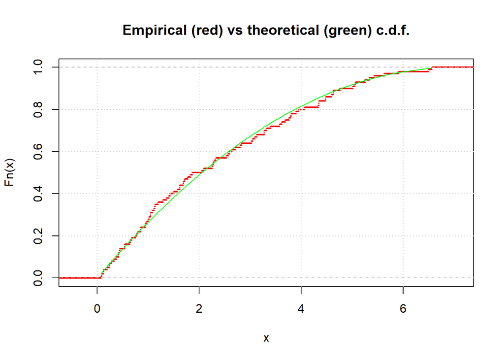

```r
# Calculations
a <- 7                # parameter
n <- 100              # sample size
U <- runif(n)         # generate uniform sample
X <- (a-a*sqrt(1-U))  # generate our sample
cdf <- ecdf(X)        # empirical cdf for X
# Plot
grd <-sort(X)         # grid for plots
plot(cdf,do.points=FALSE,col='red',lwd=2,main='Empirical (red) vs theoretical (green) c.d.f.') # plot ecdf
points(grd,-(grd*(grd-2*a))/(a^2),type='l',col='green') # add original cdf
grid() # add grid
```

**Basic Accept/Reject Method**

We will use the Accept/Reject method to generate a sample of size $n$ from the distribution given by its c.d.f. below:
$$F_Y(y) = \frac{(y-5)^{\alpha}}{(A-5)^\alpha},\quad \alpha>1, A>5, y\in(5,A).$$
As we can see, this c.d.f. has finite support on $(5,A)$. Then one can select $V\sim {\sf Uniform}(5,A)$ with p.d.f. $f_V(y) = 1/(A-5)$ for $y\in(5,A)$. The condition of step (b) from theorem 5.6.8 is then rewritten as
$$U<\frac{1}{(A-5)\max f_Y(y)}\frac{f_Y(V)}{f_V(V)}=\frac{f_Y(V)}{\max f_Y(y)}.$$
This theorem then instructs our method to do the following:

1. Generate a point ($V \sim f_V,U' \sim (\max f_Y(y))({\sf Uniform}(0,1))$) within a minimal rectangle with sides parallel to the axes that contains the graph of the p.d.f. $f_Y(y)$.
2. If the $y$-coordinate of this point, $U'$, is below the p.d.f. $f_Y(V)$, then $Y=V$. Otherwise, repeat step (a).

First, observe that the p.d.f. associated to our given distribution is
$$\frac{\alpha(y-5)^{\alpha-1}}{(A-5)^{\alpha}},\quad \alpha>1, A>5, y\in(5,A).$$
This is a monotonically increasing function and so attains maximum value at the rightmost endpoint which is evaluated to be $\frac{\alpha}{A-5}$.

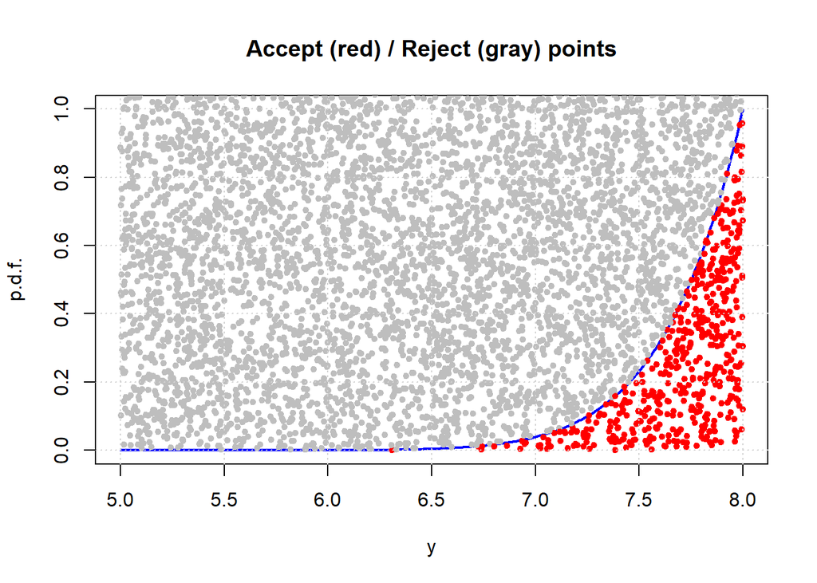

```r
# Parameters
alpha <- 8            # parameter alpha > 1
A <- 8                # parameter A > 5
n <- 500              # required sample size
M <- alpha/(A-5)      # maximum p.d.f. value
Y <- 0                # initial sample

grd = seq(5,A,by=0.01) # grid for plots, adjusting for 5<y<A
plot(grd,((grd-5)^alpha)/((A-5)^alpha),type='l',col='blue',lwd=2,
     main='Accept (red) / Reject (gray) points',
     xlab='y',ylab = 'p.d.f.') # plot p.d.f. f_Y
n0<-0 # sample size
while(n0 < n)
{
  U <- runif(1)                   # generate uniform point U
  V <- runif(1,5,A)               # generate uniform point V
  if(U*M<(((V-5)^alpha)/((A-5)^alpha)))
  # Accept
  {
    n0<-n0+1
    Y[n0] <- V
    points(V,U*M,type='p',pch=20,col='red') # add accepted point
  }
  else
  # Reject
  {points(V,U*M,type='p',pch=20,col='gray')} # add rejected point
}
grid() # add grid
```

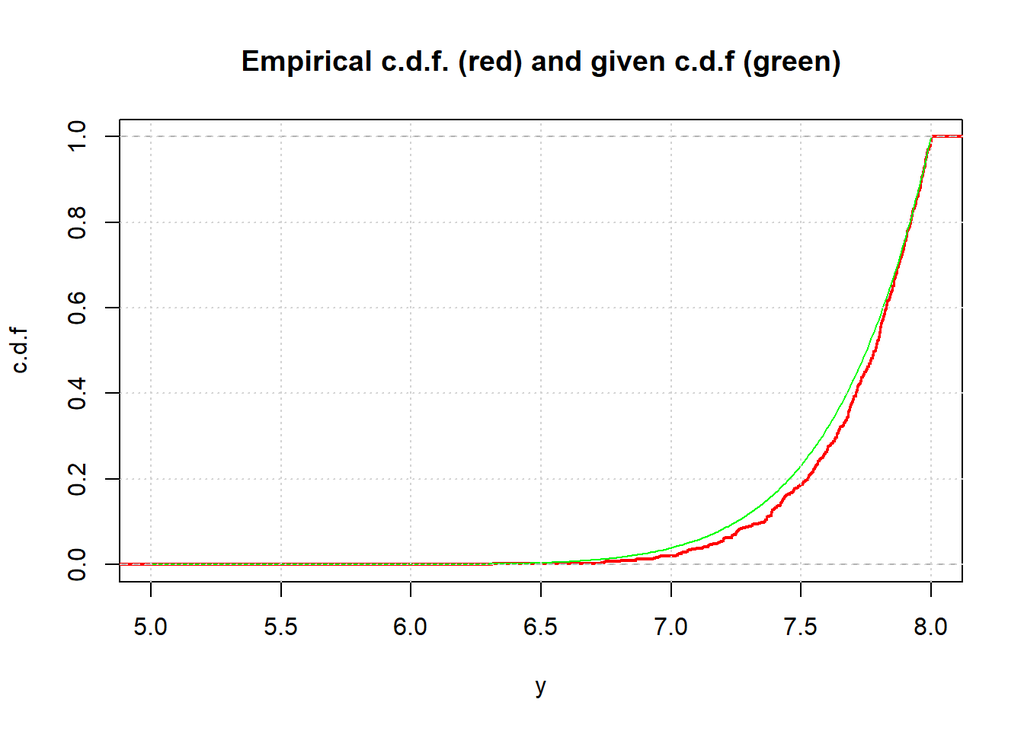

```r
plot(ecdf(Y),do.points=FALSE,col='red',lwd=2,
     main='Empirical c.d.f. (red) and given c.d.f (green)',
     ylab='c.d.f',
     xlab='y',
     xlim=c(5,A)) # plot empirical c.d.f. of the generated sample
points(grd,((grd-5)^alpha)/((A-5)^alpha),type='l',col='green',lwd=1) # add c.d.f. F_Y
grid()
```

## Assignment 3

**Sped-up Accept/Reject Method (Similar PDFs)** We will use the Accept/Reject method to generate a sample of size $n$ from a distribution given by the p.d.f below:
$$f_Y(y) = \left\{
\begin{align}
\frac{2y}{a},& \quad 0\le y \le a,\\
\frac{2(1-y)}{1-a},& \quad a< y \le 1
\end{align}
\right.,\quad 0<a<1, y\in(0,1).$$
The method will use a Beta distributed r.v. $V$. We will select the parameters via a ratio test.

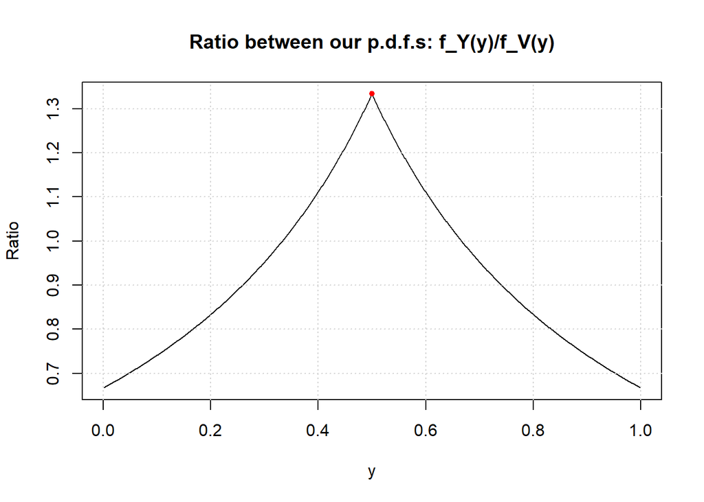

```r
# Calculations
ourPdf <- function(y,a){
out <- numeric(length = length(y))
    for(i in seq_along(y)) {
      if (y[i] <= a) {
        out[i] <- 2*y[i]/a
      }
      else {
        out[i] <- 2*(1-y[i])/(1-a)
      }
    }
    out
}

a <-0.5               # parameter a in Y
alpha1 <- 2            # parameter alpha in V
beta1 <- 2              # parameter beta in V

d <- 0.001
grd <- seq(d,1-d,by=d)

ratio <- ourPdf(grd,a)/dbeta(grd,alpha1,beta1) # ratio of p.d.f.s
M <- max(ratio) # maximum ratio value
Mx <- grd[which.max(ratio)] # maximum ratio position
plot(grd,ratio,type='l',
     main='Ratio between our p.d.f.s: f_Y(y)/f_V(y)',
     xlab='y',
     ylab ='Ratio') # plot ratio
points(Mx,M,type='p',pch=20,col='red') # add the maximum point
grid()
```

Playing around with the above code (changing the $\alpha,\beta$ and a parameters) it looks like the choice of $\alpha=2, \beta=2$ is a good integral choice to minimize the ratio so that the “envelope” is not too large. This is good for a near 0.5 but if a is more extremal this choice is extremely bad.

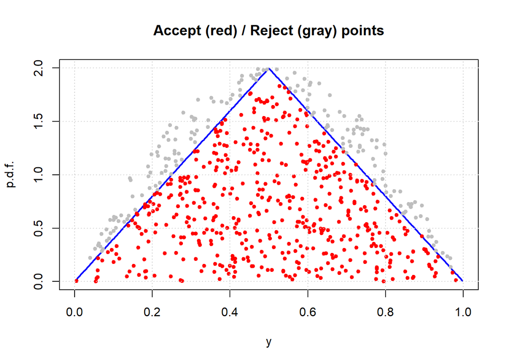

```r
n <- 500                 # required sample size

plot(grd,ourPdf(grd,a),type='l',col='blue',lwd=2,
     main='Accept (red) / Reject (gray) points',
     xlab='y',ylab = 'p.d.f.') # plot p.d.f. f_Y
Y<-0
n0<-0 # sample size
while(n0 < n)
{
  U <- runif(1)                      # generate uniform point U
  V <- rbeta(1,alpha1,beta1)         # generate Beta point V
  if(U*M<ourPdf(V,a)/dbeta(V,alpha1,beta1))
  # Accept
  {
    n0<-n0+1
    Y[n0] <- V
    points(V,U*M*dbeta(V,alpha1,beta1),type='p',pch=20,col='red')
  }
  else
  # Reject
  {points(V,U*M*dbeta(V,alpha1,beta1),type='p',pch=20,col='gray')}
}
grid() # add grid
```

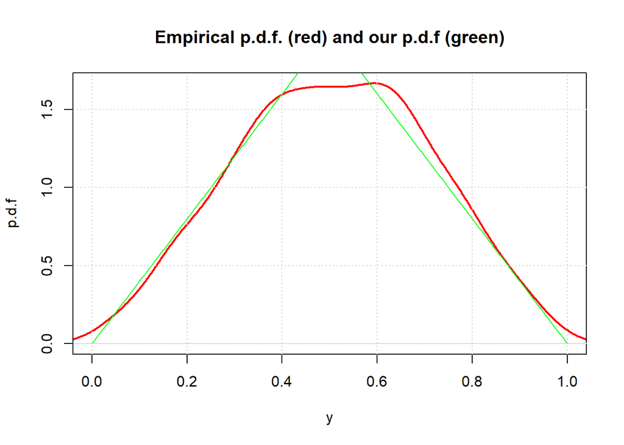

```r
plot(density(Y),col='red',lwd=2,
     main='Empirical p.d.f. (red) and our p.d.f (green)',
     ylab='p.d.f',
     xlab='y',
     xlim=c(0,1)) # plot empirical c.d.f. of Y
points(grd,ourPdf(grd,a),type='l',col='green',lwd=1) # add F_Y
grid()
```

Below is a histogram of our generated sample.

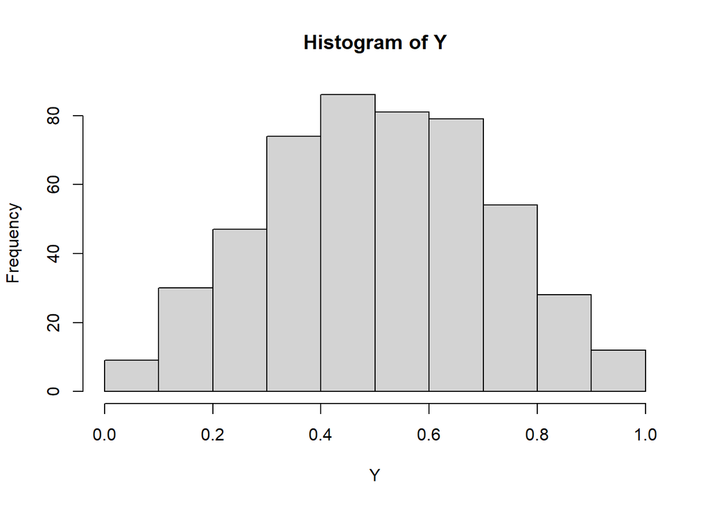

```r
hist(Y)
```